# Convolutional Neural Networks

## Project: Write an Algorithm for a Dog Identification App

In this notebook, some template code has already been provided for you, and you will need to implement additional functionality to successfully complete this project. You will not need to modify the included code beyond what is requested. Sections that begin with **'(IMPLEMENTATION)'** in the header indicate that the following block of code will require additional functionality which you must provide. Instructions will be provided for each section, and the specifics of the implementation are marked in the code block with a 'TODO' statement. Please be sure to read the instructions carefully!

> **Note**: Once you have completed all of the code implementations, you need to finalize your work by exporting the Jupyter Notebook as an HTML document. Before exporting the notebook to html, all of the code cells need to have been run so that reviewers can see the final implementation and output. You can then export the notebook by using the menu above and navigating to **File -> Download as -> HTML (.html)**. Include the finished document along with this notebook as your submission.

In addition to implementing code, there will be questions that you must answer which relate to the project and your implementation. Each section where you will answer a question is preceded by a **'Question X'** header. Carefully read each question and provide thorough answers in the following text boxes that begin with **'Answer:'**. Your project submission will be evaluated based on your answers to each of the questions and the implementation you provide.

> **Note:** Code and Markdown cells can be executed using the **Shift + Enter** keyboard shortcut. Markdown cells can be edited by double-clicking the cell to enter edit mode.

The rubric contains *optional* "Stand Out Suggestions" for enhancing the project beyond the minimum requirements. If you decide to pursue the "Stand Out Suggestions", you should include the code in this Jupyter notebook.

### Why We're Here

In this notebook, you will make the first steps towards developing an algorithm that could be used as part of a mobile or web app. At the end of this project, your code will accept any user-supplied image as input. If a dog is detected in the image, it will provide an estimate of the dog's breed. If a human is detected, it will provide an estimate of the dog breed that is most resembling. The image below displays potential sample output of your finished project (... but we expect that each student's algorithm will behave differently!).

[figure not shown]

In this real-world setting, you will need to piece together a series of models to perform different tasks; for instance, the algorithm that detects humans in an image will be different from the CNN that infers dog breed. There are many points of possible failure, and no perfect algorithm exists. Your imperfect solution will nonetheless create a fun user experience!

### The Road Ahead

We break the notebook into separate steps. Feel free to use the links below to navigate the notebook.

- Step 0: Import Datasets
- Step 1: Detect Humans
- Step 2: Detect Dogs
- Step 3: Create a CNN to Classify Dog Breeds (from Scratch)
- Step 4: Create a CNN to Classify Dog Breeds (using Transfer Learning)
- Step 5: Write your Algorithm
- Step 6: Test Your Algorithm

## Step 0: Import Datasets

Make sure that you've downloaded the required human and dog datasets:

**Note: if you are using the Udacity workspace, you *DO NOT* need to re-download these - they can be found in the `/data` folder as noted in the cell below.**

- Download the [dog dataset](https://s3-us-west-1.amazonaws.com/udacity-aind/dog-project/dogImages.zip). Unzip the folder and place it in this project's home directory, at the location `/dog_images`.
- Download the [human dataset](https://s3-us-west-1.amazonaws.com/udacity-aind/dog-project/lfw.zip). Unzip the folder and place it in the home directory, at location `/lfw`.

*Note: If you are using a Windows machine, you are encouraged to use [7zip](http://www.7-zip.org/) to extract the folder.*

In the code cell below, we save the file paths for both the human (LFW) dataset and dog dataset in the numpy arrays `human_files` and `dog_files`.

```python
import os
```

```python
os.listdir()
```

```
['dog_app-cn.ipynb',
 'model_scratch.pt',
 'README.md',
 'haarcascades',
 'a.jpg',
 'dog_app.ipynb',
 'model_transfer_unfreeeze.pt',
 'model_transfer.pt',
 '.ipynb_checkpoints',
 'images']
```

```python
!nvidia-smi
```

```
Tue May  5 06:12:01 2020
+-----------------------------------------------------------------------------+
| NVIDIA-SMI 440.33.01    Driver Version: 440.33.01    CUDA Version: 10.2     |
|-------------------------------+----------------------+----------------------+
| GPU  Name        Persistence-M| Bus-Id        Disp.A | Volatile Uncorr. ECC |
| Fan  Temp  Perf  Pwr:Usage/Cap|         Memory-Usage | GPU-Util  Compute M. |
|===============================+======================+======================|
|   0  Tesla K80           Off  | 00000000:00:04.0 Off |                    0 |
| N/A   51C    P8    31W / 149W |     16MiB / 11441MiB |      0%      Default |
+-------------------------------+----------------------+----------------------+

+-----------------------------------------------------------------------------+
| Processes:                                                       GPU Memory |
|  GPU       PID   Type   Process name                             Usage      |
|=============================================================================|
+-----------------------------------------------------------------------------+
```

```python
import numpy as np
from glob import glob
import torch
import torchvision.models as models
from PIL import Image
import torchvision.transforms as transforms
from PIL import ImageFile
ImageFile.LOAD_TRUNCATED_IMAGES = True
# load filenames for human and dog images
human_files = np.array(glob("/data/lfw/*/*"))
dog_files = np.array(glob("/data/dog_images/*/*/*"))
use_cuda = torch.cuda.is_available()
from tqdm import tqdm
# print number of images in each dataset
print('There are %d total human images.' % len(human_files))
print('There are %d total dog images.' % len(dog_files))
```

```
There are 13233 total human images.
There are 8351 total dog images.
```

## Step 1: Detect Humans

In this section, we use OpenCV's implementation of [Haar feature-based cascade classifiers](http://docs.opencv.org/trunk/d7/d8b/tutorial_py_face_detection.html) to detect human faces in images.

OpenCV provides many pre-trained face detectors, stored as XML files on [github](https://github.com/opencv/opencv/tree/master/data/haarcascades). We have downloaded one of these detectors and stored it in the `haarcascades` directory. In the next code cell, we demonstrate how to use this detector to find human faces in a sample image.

```
Number of faces detected: 1
```

```python
import cv2
import matplotlib.pyplot as plt
%matplotlib inline

# extract pre-trained face detector
face_cascade = cv2.CascadeClassifier('haarcascades/haarcascade_frontalface_alt.xml')

# load color (BGR) image
img = cv2.imread(human_files[0])
# convert BGR image to grayscale
gray = cv2.cvtColor(img, cv2.COLOR_BGR2GRAY)

# find faces in image
faces = face_cascade.detectMultiScale(gray)

# print number of faces detected in the image
print('Number of faces detected:', len(faces))

# get bounding box for each detected face
for (x,y,w,h) in faces:
    # add bounding box to color image
    cv2.rectangle(img,(x,y),(x+w,y+h),(255,0,0),2)

# convert BGR image to RGB for plotting
cv_rgb = cv2.cvtColor(img, cv2.COLOR_BGR2RGB)

# display the image, along with bounding box
plt.imshow(cv_rgb)
plt.show()
```

Before using any of the face detectors, it is standard procedure to convert the images to grayscale. The `detectMultiScale` function executes the classifier stored in `face_cascade` and takes the grayscale image as a parameter.

In the above code, `faces` is a numpy array of detected faces, where each row corresponds to a detected face. Each detected face is a 1D array with four entries that specifies the bounding box of the detected face. The first two entries in the array (extracted in the above code as `x` and `y`) specify the horizontal and vertical positions of the top left corner of the bounding box. The last two entries in the array (extracted here as `w` and `h`) specify the width and height of the box.

### Write a Human Face Detector

We can use this procedure to write a function that returns `True` if a human face is detected in an image and `False` otherwise. This function, aptly named `face_detector`, takes a string-valued file path to an image as input and appears in the code block below.

```python
# returns "True" if face is detected in image stored at img_path
def face_detector(img_path):
    img = cv2.imread(img_path)
    gray = cv2.cvtColor(img, cv2.COLOR_BGR2GRAY)
    faces = face_cascade.detectMultiScale(gray)
    return len(faces) > 0
```

### (IMPLEMENTATION) Assess the Human Face Detector

**Question 1:** Use the code cell below to test the performance of the `face_detector` function.

- What percentage of the first 100 images in `human_files` have a detected human face?
- What percentage of the first 100 images in `dog_files` have a detected human face?

Ideally, we would like 100% of human images with a detected face and 0% of dog images with a detected face. You will see that our algorithm falls short of this goal, but still gives acceptable performance. We extract the file paths for the first 100 images from each of the datasets and store them in the numpy arrays `human_files_short` and `dog_files_short`.

```python
from tqdm import tqdm

human_files_short = human_files[:100]
dog_files_short = dog_files[:100]

#-#-# Do NOT modify the code above this line. #-#-#

## TODO: Test the performance of the face_detector algorithm
## on the images in human_files_short and dog_files_short.
human_count=0
dog_count=0
for img in tqdm(human_files_short):
    if face_detector(img):
        human_count+=1
for img in tqdm(dog_files_short):
    if not face_detector(img):
        dog_count+=1
print(f"This algorithm found {human_count}% human images and {dog_count}% dog images.")
```

```
This algorithm found 98% human images and 83% dog images.
```

We suggest the face detector from OpenCV as a potential way to detect human images in your algorithm, but you are free to explore other approaches, especially approaches that make use of deep learning :). Please use the code cell below to design and test your own face detection algorithm. If you decide to pursue this *optional* task, report performance on `human_files_short` and `dog_files_short`.

```python
### (Optional)
### TODO: Test performance of anotherface detection algorithm.
### Feel free to use as many code cells as needed.
```

## Step 2: Detect Dogs

In this section, we use a [pre-trained model](http://pytorch.org/docs/master/torchvision/models.html) to detect dogs in images.

### Obtain Pre-trained VGG-16 Model

The code cell below downloads the VGG-16 model, along with weights that have been trained on [ImageNet](http://www.image-net.org/), a very large, very popular dataset used for image classification and other vision tasks. ImageNet contains over 10 million URLs, each linking to an image containing an object from one of [1000 categories](https://gist.github.com/yrevar/942d3a0ac09ec9e5eb3a).

```python
import torch
import torchvision.models as models

# define VGG16 model
VGG16 = models.vgg16(pretrained=True)

# check if CUDA is available
use_cuda = torch.cuda.is_available()

# move model to GPU if CUDA is available
if use_cuda:
    VGG16 = VGG16.cuda()
for param in VGG16.parameters():
    param.requires_grad = False
```

```
Downloading: "https://download.pytorch.org/models/vgg16-397923af.pth" to /root/.torch/models/vgg16-397923af.pth
```

Given an image, this pre-trained VGG-16 model returns a prediction (derived from the 1000 possible categories in ImageNet) for the object that is contained in the image.

### (IMPLEMENTATION) Making Predictions with a Pre-trained Model

In the next code cell, you will write a function that accepts a path to an image (such as `'dogImages/train/001.Affenpinscher/Affenpinscher_00001.jpg'`) as input and returns the index corresponding to the ImageNet class that is predicted by the pre-trained VGG-16 model. The output should always be an integer between 0 and 999, inclusive.

Before writing the function, make sure that you take the time to learn how to appropriately pre-process tensors for pre-trained models in the [PyTorch documentation](http://pytorch.org/docs/stable/torchvision/models.html).

```python
from PIL import Image
import torchvision.transforms as transforms

def VGG16_predict(img_path):
    '''
    Use pre-trained VGG-16 model to obtain index corresponding to
    predicted ImageNet class for image at specified path

    Args:
        img_path: path to an image

    Returns:
        Index corresponding to VGG-16 model's prediction
    '''

    ## TODO: Complete the function.
    ## Load and pre-process an image from the given img_path
    ## Return the *index* of the predicted class for that image
    img=Image.open(img_path)
    transform=transforms.Compose([transforms.Resize((224,224))  ,transforms.ToTensor(), transforms.Normalize(mean=[0.485, 0.456, 0.406],
                                 std=[0.229, 0.224, 0.225])])
    img=transform(img)
    if use_cuda:
        pred=VGG16(img.unsqueeze(0).cuda())
    else:
        pred=VGG16(img.unsqueeze(0))
    return torch.argmax(pred) # predicted class index
```

### (IMPLEMENTATION) Write a Dog Detector

While looking at the [dictionary](https://gist.github.com/yrevar/942d3a0ac09ec9e5eb3a), you will notice that the categories corresponding to dogs appear in an uninterrupted sequence and correspond to dictionary keys 151-268, inclusive, to include all categories from `'Chihuahua'` to `'Mexican hairless'`. Thus, in order to check to see if an image is predicted to contain a dog by the pre-trained VGG-16 model, we need only check if the pre-trained model predicts an index between 151 and 268 (inclusive).

Use these ideas to complete the `dog_detector` function below, which returns `True` if a dog is detected in an image (and `False` if not).

```python
### returns "True" if a dog is detected in the image stored at img_path
def dog_detector(img_path):
    ## TODO: Complete the function.
    idx=VGG16_predict(img_path)
    if idx in range(151,269):
        return True
    else:
        return False
    # true/false
```

### (IMPLEMENTATION) Assess the Dog Detector

**Question 2:** Use the code cell below to test the performance of your `dog_detector` function.

- What percentage of the images in `human_files_short` have a detected dog?
- What percentage of the images in `dog_files_short` have a detected dog?

**Answer:** percentage of dogs in human_files_short is 1% and percentage of dogs in dog_files_short is 100%

```python
### TODO: Test the performance of the dog_detector function
### on the images in human_files_short and dog_files_short.
dog_in_human_count=0
dog_count=0
for img in  tqdm(human_files_short):
    if dog_detector(img):
        dog_in_human_count+=1
for img in tqdm(dog_files_short):
    if dog_detector(img):
        dog_count+=1
print(f'percentage of dogs in human_files_short is {dog_in_human_count}% and percentage of dogs in dog_files_short is {dog_count}%')
```

```
percentage of dogs in human_files_short is 1% and percentage of dogs in dog_files_short is 100%
```

We suggest VGG-16 as a potential network to detect dog images in your algorithm, but you are free to explore other pre-trained networks (such as [Inception-v3](http://pytorch.org/docs/master/torchvision/models.html#inception-v3), [ResNet-50](http://pytorch.org/docs/master/torchvision/models.html#id3), etc). Please use the code cell below to test other pre-trained PyTorch models. If you decide to pursue this *optional* task, report performance on `human_files_short` and `dog_files_short`.

```python
### (Optional)
### TODO: Report the performance of another pre-trained network.
### Feel free to use as many code cells as needed.
```

## Step 3: Create a CNN to Classify Dog Breeds (from Scratch)

Now that we have functions for detecting humans and dogs in images, we need a way to predict breed from images. In this step, you will create a CNN that classifies dog breeds. You must create your CNN *from scratch* (so, you can't use transfer learning *yet*!), and you must attain a test accuracy of at least 10%. In Step 4 of this notebook, you will have the opportunity to use transfer learning to create a CNN that attains greatly improved accuracy.

We mention that the task of assigning breed to dogs from images is considered exceptionally challenging. To see why, consider that *even a human* would have trouble distinguishing between a Brittany and a Welsh Springer Spaniel.

| Brittany | Welsh Springer Spaniel |
| --- | --- |

It is not difficult to find other dog breed pairs with minimal inter-class variation (for instance, Curly-Coated Retrievers and American Water Spaniels).

| Curly-Coated Retriever | American Water Spaniel |
| --- | --- |

Likewise, recall that labradors come in yellow, chocolate, and black. Your vision-based algorithm will have to conquer this high intra-class variation to determine how to classify all of these different shades as the same breed.

| Yellow Labrador | Chocolate Labrador | Black Labrador |
| --- | --- | --- |

We also mention that random chance presents an exceptionally low bar: setting aside the fact that the classes are slightly imabalanced, a random guess will provide a correct answer roughly 1 in 133 times, which corresponds to an accuracy of less than 1%.

Remember that the practice is far ahead of the theory in deep learning. Experiment with many different architectures, and trust your intuition. And, of course, have fun!

### (IMPLEMENTATION) Specify Data Loaders for the Dog Dataset

Use the code cell below to write three separate [data loaders](http://pytorch.org/docs/stable/data.html#torch.utils.data.DataLoader) for the training, validation, and test datasets of dog images (located at `dog_images/train`, `dog_images/valid`, and `dog_images/test`, respectively). You may find [this documentation on custom datasets](http://pytorch.org/docs/stable/torchvision/datasets.html) to be a useful resource. If you are interested in augmenting your training and/or validation data, check out the wide variety of [transforms](http://pytorch.org/docs/stable/torchvision/transforms.html?highlight=transform)!

```python
import os
from torchvision import datasets

### TODO: Write data loaders for training, validation, and test sets
## Specify appropriate transforms, and batch_sizes
batch_size=64
transform=transforms.Compose([transforms.RandomResizedCrop(224) ,transforms.RandomRotation(20),transforms.RandomHorizontalFlip(),transforms.ToTensor(), transforms.Normalize(mean=[0.485, 0.456, 0.406],
                                 std=[0.229, 0.224, 0.225])])
test_transform=transforms.Compose([transforms.Resize((224,224)),transforms.ToTensor(), transforms.Normalize(mean=[0.485, 0.456, 0.406],
                                 std=[0.229, 0.224, 0.225])])
valid_transform=transforms.Compose([transforms.Resize((224,224)),transforms.ToTensor(), transforms.Normalize(mean=[0.485, 0.456, 0.406],
                                 std=[0.229, 0.224, 0.225])])
train_data=datasets.ImageFolder('/data/dog_images/train/',transform=transform)

valid_data=datasets.ImageFolder('/data/dog_images/valid/',transform=valid_transform)

test_data=datasets.ImageFolder('/data/dog_images/test/',transform=test_transform)

train_loader=torch.utils.data.DataLoader(train_data,batch_size=batch_size,shuffle=True,num_workers=0)
valid_loader=torch.utils.data.DataLoader(valid_data,batch_size=batch_size,num_workers=0)
test_loader=torch.utils.data.DataLoader(test_data,batch_size=batch_size,num_workers=0)
loaders_scratch={'train':train_loader,'valid':valid_loader,'test':test_loader}
```

**Question 3:** Describe your chosen procedure for preprocessing the data.

- How does your code resize the images (by cropping, stretching, etc)? What size did you pick for the input tensor, and why?
- Did you decide to augment the dataset? If so, how (through translations, flips, rotations, etc)? If not, why not?

**Answer**: I have resized the images using random-resized-crop and i have chosen the size as 224 for training on pretrained architecture. Yes, i have used some augmentations like random rotation and random horizontal-flip. Rotation will help identify some features better and horizontal flip gives mirror image which should be great for dog images and will increase the amount of information.

For the validation and test data i have not used any augmentations but resizing the images and normalizing them.

### (IMPLEMENTATION) Model Architecture

Create a CNN to classify dog breed. Use the template in the code cell below.

```python
import torch.nn as nn
import torch.nn.functional as F

# define the CNN architecture
class Net(nn.Module):
    ### TODO: choose an architecture, and complete the class
    def __init__(self):
        super(Net, self).__init__()
        ## Define layers of a CNN
        self.conv1=nn.Conv2d(3,32,3,padding=1)# 3*224*224->32*112*112
        self.conv2=nn.Conv2d(32,128,3,padding=1)#32*112*112->128*56*56
        self.conv3=nn.Conv2d(128,256,3,padding=1)#128*56*56->256*28*28
        self.pool=nn.MaxPool2d(2,2)
        self.drop=nn.Dropout(0.4)
        self.fc1=nn.Linear(256*28*28,256)#256*28*28->256
        self.out=nn.Linear(256,133)#256->133
    def forward(self, x):
        ## Define forward behavior
        x=F.relu(self.conv1(x))
        x=self.pool(x)
        x=F.relu(self.conv2(x))
        x=self.pool(x)
        x=F.relu(self.conv3(x))
        x=self.pool(x)
        x=x.view(-1,256*28*28)
        x=F.relu(self.fc1(x))
        x=self.drop(x)
        x=self.out(x)
        return x

#-#-# You so NOT have to modify the code below this line. #-#-#

# instantiate the CNN
model_scratch = Net()

# move tensors to GPU if CUDA is available
if use_cuda:
    model_scratch.cuda()
```

```python
print(model_scratch)
```

```
Net(
  (conv1): Conv2d(3, 32, kernel_size=(3, 3), stride=(1, 1), padding=(1, 1))
  (conv2): Conv2d(32, 128, kernel_size=(3, 3), stride=(1, 1), padding=(1, 1))
  (conv3): Conv2d(128, 256, kernel_size=(3, 3), stride=(1, 1), padding=(1, 1))
  (pool): MaxPool2d(kernel_size=2, stride=2, padding=0, dilation=1, ceil_mode=False)
  (drop): Dropout(p=0.4)
  (fc1): Linear(in_features=200704, out_features=256, bias=True)
  (out): Linear(in_features=256, out_features=133, bias=True)
)
```

**Question 4:** Outline the steps you took to get to your final CNN architecture and your reasoning at each step.

**Answer:**

1. the input is RGB image cropped into 224x224 pixel and the depth is 3 (3 colors), we will have our input with the shape of 3x224x224 .
2. There are 3 convolutional layers with relu activation function and one max pooling layer(2,2), the first layer takes (3,224,224) input and converted it into a depth of 32 layers, the filter used was 3x3 with stride of 1 and padding of 1 in order to not get rid of edges:

   ```
        first convolutional layer (sees 224x224x3 image tensor).
        second convolutional layer (sees 112x112x32 tensor).
        third convolutional layer (sees 56x56x128 tensor).
   ```

   one pool layer (2,2) was used in order to reduce the size of the images to half.
3. Then flatten image input using view function to reshape the tensor.
4. Then, two full connected Linear layers with relu activation function were added, and dropout layers for the hidden layers with a percentage of 40% to avoid overfitting:

   ```
    first linear layer (256x28x28 -> 256).
    second linear layer (256 -> 133), as the output classes is 133
   ```

### (IMPLEMENTATION) Specify Loss Function and Optimizer

Use the next code cell to specify a [loss function](http://pytorch.org/docs/stable/nn.html#loss-functions) and [optimizer](http://pytorch.org/docs/stable/optim.html). Save the chosen loss function as `criterion_scratch`, and the optimizer as `optimizer_scratch` below.

```python
import torch.optim as optim
### TODO: select loss function
criterion_scratch = nn.CrossEntropyLoss()

### TODO: select optimizer
optimizer_scratch = optim.Adam(model_scratch.parameters())
```

### (IMPLEMENTATION) Train and Validate the Model

Train and validate your model in the code cell below. [Save the final model parameters](http://pytorch.org/docs/master/notes/serialization.html) at filepath `'model_scratch.pt'`.

```python
def train(n_epochs, loaders, model, optimizer, criterion, use_cuda, save_path):
    """returns trained model"""
    # initialize tracker for minimum validation loss
    valid_loss_min = np.Inf

    for epoch in (range(1, n_epochs+1)):
        # initialize variables to monitor training and validation loss
        train_loss = 0.0
        valid_loss = 0.0

        ###################
        # train the model #
        ###################
        model.train()
        for batch_idx, (data, target) in tqdm(enumerate(loaders['train'])):
            # move to GPU
            if use_cuda:
                data, target = data.cuda(), target.cuda()
            ## find the loss and update the model parameters accordingly
            ## record the average training loss, using something like
            ## train_loss = train_loss + ((1 / (batch_idx + 1)) * (loss.data - train_loss))
            optimizer.zero_grad()
            output=model(data)
            loss=criterion(output,target)
            loss.backward()
            optimizer.step()
            train_loss = train_loss + ((1 / (batch_idx + 1)) * (loss.data - train_loss))
#             train_loss += loss.item()*data.size(0)
        ######################
        # validate the model #
        ######################
        model.eval()
        for batch_idx, (data, target) in tqdm(enumerate(loaders['valid'])):
            # move to GPU
            if use_cuda:
                data, target = data.cuda(), target.cuda()
            ## update the average validation loss
            output=model(data)
            loss=criterion(output,target)
#             valid_loss += loss.item()*data.size(0)
            valid_loss = valid_loss + ((1 / (batch_idx + 1)) * (loss.data - valid_loss))
#         train_loss = train_loss/len(loaders['train'].sampler)
#         valid_loss = valid_loss/len(loaders['valid'].sampler)

        # print training/validation statistics
        print('Epoch: {} \tTraining Loss: {:.6f} \tValidation Loss: {:.6f}'.format(
            epoch,
            train_loss,
            valid_loss
            ))

        ## TODO: save the model if validation loss has decreased
        if valid_loss <= valid_loss_min:
            print('Validation loss decreased ({:.6f} --> {:.6f}).  Saving model ...'.format(
            valid_loss_min,
            valid_loss))
            torch.save(model.state_dict(), save_path)
            valid_loss_min = valid_loss
    # return trained model
    return model


# train the model
model_scratch = train(40, loaders_scratch, model_scratch, optimizer_scratch,
                      criterion_scratch, use_cuda, 'model_scratch.pt')

# load the model that got the best validation accuracy
model_scratch.load_state_dict(torch.load('model_scratch.pt'))
```

[output not shown]

[output cut: 67 more lines]

[output not shown]

```
Epoch: 1 	Training Loss: 4.971089 	Validation Loss: 4.872899
Validation loss decreased (inf --> 4.872899).  Saving model ...
```

[output not shown]

[output cut: 67 more lines]

[output not shown]

```
Epoch: 2 	Training Loss: 4.798288 	Validation Loss: 4.720921
Validation loss decreased (4.872899 --> 4.720921).  Saving model ...
```

[output not shown]

[output cut: 67 more lines]

[output not shown]

```
Epoch: 3 	Training Loss: 4.667113 	Validation Loss: 4.527084
Validation loss decreased (4.720921 --> 4.527084).  Saving model ...
```

[output not shown]

[output cut: 67 more lines]

[output not shown]

```
Epoch: 4 	Training Loss: 4.539203 	Validation Loss: 4.505744
Validation loss decreased (4.527084 --> 4.505744).  Saving model ...
```

[output not shown]

[output cut: 67 more lines]

[output not shown]

```
Epoch: 5 	Training Loss: 4.473325 	Validation Loss: 4.430807
Validation loss decreased (4.505744 --> 4.430807).  Saving model ...
```

[output not shown]

[output cut: 67 more lines]

[output not shown]

```
Epoch: 6 	Training Loss: 4.405877 	Validation Loss: 4.397927
Validation loss decreased (4.430807 --> 4.397927).  Saving model ...
```

[output not shown]

[output cut: 69 more lines]

[output not shown]

```
Epoch: 7 	Training Loss: 4.349707 	Validation Loss: 4.605506
```

[output not shown]

[output cut: 66 more lines]

[output not shown]

```
Epoch: 8 	Training Loss: 4.290856 	Validation Loss: 4.352392
Validation loss decreased (4.397927 --> 4.352392).  Saving model ...
```

[output not shown]

[output cut: 67 more lines]

[output not shown]

```
Epoch: 9 	Training Loss: 4.216397 	Validation Loss: 4.255473
Validation loss decreased (4.352392 --> 4.255473).  Saving model ...
```

[output not shown]

[output cut: 67 more lines]

[output not shown]

```
Epoch: 10 	Training Loss: 4.197481 	Validation Loss: 4.237704
Validation loss decreased (4.255473 --> 4.237704).  Saving model ...
```

[output not shown]

[output cut: 67 more lines]

[output not shown]

```
Epoch: 11 	Training Loss: 4.153792 	Validation Loss: 4.235958
Validation loss decreased (4.237704 --> 4.235958).  Saving model ...
```

[output not shown]

[output cut: 67 more lines]

[output not shown]

```
Epoch: 12 	Training Loss: 4.110844 	Validation Loss: 4.196635
Validation loss decreased (4.235958 --> 4.196635).  Saving model ...
```

[output not shown]

[output cut: 67 more lines]

[output not shown]

```
Epoch: 13 	Training Loss: 4.099779 	Validation Loss: 3.966033
Validation loss decreased (4.196635 --> 3.966033).  Saving model ...
```

[output not shown]

[output cut: 69 more lines]

[output not shown]

```
Epoch: 14 	Training Loss: 4.039999 	Validation Loss: 4.068476
```

[output not shown]

[output cut: 68 more lines]

[output not shown]

```
Epoch: 15 	Training Loss: 4.002746 	Validation Loss: 4.066678
```

[output not shown]

[output cut: 68 more lines]

[output not shown]

```
Epoch: 16 	Training Loss: 3.937652 	Validation Loss: 4.177444
```

[output not shown]

[output cut: 68 more lines]

[output not shown]

```
Epoch: 17 	Training Loss: 3.931904 	Validation Loss: 4.155424
```

[output not shown]

[output cut: 66 more lines]

[output not shown]

```
Epoch: 18 	Training Loss: 3.850554 	Validation Loss: 3.959233
Validation loss decreased (3.966033 --> 3.959233).  Saving model ...
```

[output not shown]

[output cut: 69 more lines]

[output not shown]

```
Epoch: 19 	Training Loss: 3.831647 	Validation Loss: 4.074507
```

[output not shown]

[output cut: 68 more lines]

[output not shown]

```
Epoch: 20 	Training Loss: 3.799805 	Validation Loss: 3.992515
```

[output not shown]

[output cut: 66 more lines]

[output not shown]

```
Epoch: 21 	Training Loss: 3.769598 	Validation Loss: 3.843314
Validation loss decreased (3.959233 --> 3.843314).  Saving model ...
```

[output not shown]

[output cut: 69 more lines]

[output not shown]

```
Epoch: 22 	Training Loss: 3.729974 	Validation Loss: 3.901429
```

[output not shown]

[output cut: 68 more lines]

[output not shown]

```
Epoch: 23 	Training Loss: 3.716680 	Validation Loss: 3.961261
```

[output not shown]

[output cut: 66 more lines]

[output not shown]

```
Epoch: 24 	Training Loss: 3.674015 	Validation Loss: 3.797165
Validation loss decreased (3.843314 --> 3.797165).  Saving model ...
```

[output not shown]

[output cut: 69 more lines]

[output not shown]

```
Epoch: 25 	Training Loss: 3.657556 	Validation Loss: 3.800741
```

[output not shown]

[output cut: 66 more lines]

[output not shown]

```
Epoch: 26 	Training Loss: 3.616070 	Validation Loss: 3.722124
Validation loss decreased (3.797165 --> 3.722124).  Saving model ...
```

[output not shown]

[output cut: 67 more lines]

[output not shown]

```
Epoch: 27 	Training Loss: 3.572915 	Validation Loss: 3.689084
Validation loss decreased (3.722124 --> 3.689084).  Saving model ...
```

[output not shown]

[output cut: 69 more lines]

[output not shown]

```
Epoch: 28 	Training Loss: 3.581644 	Validation Loss: 3.698679
```

[output not shown]

[output cut: 68 more lines]

[output not shown]

```
Epoch: 29 	Training Loss: 3.537462 	Validation Loss: 3.751118
```

[output not shown]

[output cut: 68 more lines]

[output not shown]

```
Epoch: 30 	Training Loss: 3.512278 	Validation Loss: 3.785555
```

[output not shown]

[output cut: 66 more lines]

[output not shown]

```
Epoch: 31 	Training Loss: 3.482007 	Validation Loss: 3.576481
Validation loss decreased (3.689084 --> 3.576481).  Saving model ...
```

[output not shown]

[output cut: 69 more lines]

[output not shown]

```
Epoch: 32 	Training Loss: 3.468336 	Validation Loss: 3.587905
```

[output not shown]

[output cut: 68 more lines]

[output not shown]

```
Epoch: 33 	Training Loss: 3.452052 	Validation Loss: 3.697670
```

[output not shown]

[output cut: 68 more lines]

[output not shown]

```
Epoch: 34 	Training Loss: 3.437306 	Validation Loss: 3.682895
```

[output not shown]

[output cut: 68 more lines]

[output not shown]

```
Epoch: 35 	Training Loss: 3.397449 	Validation Loss: 3.650330
```

[output not shown]

[output cut: 66 more lines]

[output not shown]

```
Epoch: 36 	Training Loss: 3.376402 	Validation Loss: 3.516158
Validation loss decreased (3.576481 --> 3.516158).  Saving model ...
```

[output not shown]

[output cut: 69 more lines]

[output not shown]

```
Epoch: 37 	Training Loss: 3.336059 	Validation Loss: 3.677362
```

[output not shown]

[output cut: 68 more lines]

[output not shown]

```
Epoch: 38 	Training Loss: 3.352641 	Validation Loss: 3.546766
```

[output not shown]

[output cut: 68 more lines]

[output not shown]

```
Epoch: 39 	Training Loss: 3.337543 	Validation Loss: 3.658505
```

[output not shown]

[output cut: 66 more lines]

[output not shown]

```
Epoch: 40 	Training Loss: 3.312838 	Validation Loss: 3.717895
```

### (IMPLEMENTATION) Test the Model

Try out your model on the test dataset of dog images. Use the code cell below to calculate and print the test loss and accuracy. Ensure that your test accuracy is greater than 10%.

```python
def test(loaders, model, criterion, use_cuda):

    # monitor test loss and accuracy
    test_loss = 0.
    correct = 0.
    total = 0.

    model.eval()
    for batch_idx, (data, target) in enumerate(loaders['test']):
        # move to GPU
        if use_cuda:
            data, target = data.cuda(), target.cuda()
        # forward pass: compute predicted outputs by passing inputs to the model
        output = model(data)
        # calculate the loss
        loss = criterion(output, target)
        # update average test loss
        test_loss = test_loss + ((1 / (batch_idx + 1)) * (loss.data - test_loss))
        # convert output probabilities to predicted class
        pred = output.data.max(1, keepdim=True)[1]
        # compare predictions to true label
        correct += np.sum(np.squeeze(pred.eq(target.data.view_as(pred))).cpu().numpy())
        total += data.size(0)

    print('Test Loss: {:.6f}\n'.format(test_loss))

    print('\nTest Accuracy: %2d%% (%2d/%2d)' % (
        100. * correct / total, correct, total))

# call test function
# test(loaders_scratch, model_scratch, criterion_scratch, use_cuda)
```

```python
test(loaders_scratch, model_scratch, criterion_scratch, use_cuda)
```

```
Test Loss: 3.652923


Test Accuracy: 15% (130/836)
```

## Step 4: Create a CNN to Classify Dog Breeds (using Transfer Learning)

You will now use transfer learning to create a CNN that can identify dog breed from images. Your CNN must attain at least 60% accuracy on the test set.

### (IMPLEMENTATION) Specify Data Loaders for the Dog Dataset

Use the code cell below to write three separate [data loaders](http://pytorch.org/docs/master/data.html#torch.utils.data.DataLoader) for the training, validation, and test datasets of dog images (located at `dogImages/train`, `dogImages/valid`, and `dogImages/test`, respectively).

If you like, **you are welcome to use the same data loaders from the previous step**, when you created a CNN from scratch.

```python
## TODO: Specify data loaders
from torchvision import datasets,transforms

batch_size=8

transform=transforms.Compose([transforms.RandomResizedCrop(224) ,transforms.RandomRotation(20),transforms.RandomHorizontalFlip(),transforms.ToTensor(), transforms.Normalize(mean=[0.485, 0.456, 0.406],
                                 std=[0.229, 0.224, 0.225])])
test_transform=transforms.Compose([transforms.Resize((224,224)),transforms.ToTensor(), transforms.Normalize(mean=[0.485, 0.456, 0.406],
                                 std=[0.229, 0.224, 0.225])])
valid_transform=transforms.Compose([transforms.Resize((224,224)),transforms.ToTensor(), transforms.Normalize(mean=[0.485, 0.456, 0.406],
                                 std=[0.229, 0.224, 0.225])])
train_data=datasets.ImageFolder('/data/dog_images/train/',transform=transform)

valid_data=datasets.ImageFolder('/data/dog_images/valid/',transform=valid_transform)

test_data=datasets.ImageFolder('/data/dog_images/test/',transform=test_transform)

train_loader=torch.utils.data.DataLoader(train_data,batch_size=batch_size,shuffle=True,num_workers=0)

valid_loader=torch.utils.data.DataLoader(valid_data,batch_size=batch_size,num_workers=0)

test_loader=torch.utils.data.DataLoader(test_data,batch_size=batch_size,num_workers=0)

loaders_transfer={'train':train_loader,'valid':valid_loader,'test':test_loader}
```

### (IMPLEMENTATION) Model Architecture

Use transfer learning to create a CNN to classify dog breed. Use the code cell below, and save your initialized model as the variable `model_transfer`.

```python
import torchvision.models as models
import torch.nn as nn

## TODO: Specify model architecture
model_transfer = models.vgg16(pretrained=True)

for param in model_transfer.features.parameters():
    param.requires_grad = False

n_inputs = model_transfer.classifier[6].in_features
last_layer = nn.Linear(n_inputs, 133)

model_transfer.classifier[6] = last_layer


if use_cuda:
    model_transfer = model_transfer.cuda()
```

**Question 5:** Outline the steps you took to get to your final CNN architecture and your reasoning at each step. Describe why you think the architecture is suitable for the current problem.

### (IMPLEMENTATION) Specify Loss Function and Optimizer

Use the next code cell to specify a [loss function](http://pytorch.org/docs/master/nn.html#loss-functions) and [optimizer](http://pytorch.org/docs/master/optim.html). Save the chosen loss function as `criterion_transfer`, and the optimizer as `optimizer_transfer` below.

```python
from torch import optim
criterion_transfer = nn.CrossEntropyLoss()
optimizer_transfer = optim.SGD(model_transfer.classifier.parameters(), lr=0.001)
```

### (IMPLEMENTATION) Train and Validate the Model

Train and validate your model in the code cell below. [Save the final model parameters](http://pytorch.org/docs/master/notes/serialization.html) at filepath `'model_transfer.pt'`.

```python
def train(n_epochs, loaders, model, optimizer, criterion, use_cuda, save_path):
    """returns trained model"""
    # initialize tracker for minimum validation loss
    valid_loss_min = np.Inf

    for epoch in tqdm(range(1, n_epochs+1)):
        # initialize variables to monitor training and validation loss
        train_loss = 0.0
        valid_loss = 0.0

        ###################
        # train the model #
        ###################
        model.train()
        for batch_idx, (data, target) in (enumerate(loaders['train'])):
            # move to GPU
            if use_cuda:
                data, target = data.cuda(), target.cuda()
            ## find the loss and update the model parameters accordingly
            ## record the average training loss, using something like
            ## train_loss = train_loss + ((1 / (batch_idx + 1)) * (loss.data - train_loss))
            optimizer.zero_grad()
            output=model(data)
            loss=criterion(output,target)
            loss.backward()
            optimizer.step()
            train_loss = train_loss + ((1 / (batch_idx + 1)) * (loss.data - train_loss))
#             train_loss += loss.item()*data.size(0)
        ######################
        # validate the model #
        ######################
        model.eval()
        for batch_idx, (data, target) in (enumerate(loaders['valid'])):
            # move to GPU
            if use_cuda:
                data, target = data.cuda(), target.cuda()
            ## update the average validation loss
            output=model(data)
            loss=criterion(output,target)
#             valid_loss += loss.item()*data.size(0)
            valid_loss = valid_loss + ((1 / (batch_idx + 1)) * (loss.data - valid_loss))
#         train_loss = train_loss/len(loaders['train'].sampler)
#         valid_loss = valid_loss/len(loaders['valid'].sampler)

        # print training/validation statistics
        print('Epoch: {} \tTraining Loss: {:.6f} \tValidation Loss: {:.6f}'.format(
            epoch,
            train_loss,
            valid_loss
            ))

        ## TODO: save the model if validation loss has decreased
        if valid_loss <= valid_loss_min:
            print('Validation loss decreased ({:.6f} --> {:.6f}).  Saving model ...'.format(
            valid_loss_min,
            valid_loss))
            torch.save(model.state_dict(), save_path)
            valid_loss_min = valid_loss
    # return trained model
    return model
```

```python
# train the model
model_transfer = train(15, loaders_transfer, model_transfer, optimizer_transfer, criterion_transfer, use_cuda, 'model_transfer.pt')

# load the model that got the best validation accuracy (uncomment the line below)
```

```
Epoch: 1 	Training Loss: 3.548433 	Validation Loss: 1.349157
Validation loss decreased (inf --> 1.349157).  Saving model ...
```

```
Epoch: 2 	Training Loss: 1.895075 	Validation Loss: 0.788231
Validation loss decreased (1.349157 --> 0.788231).  Saving model ...
```

```
Epoch: 3 	Training Loss: 1.535897 	Validation Loss: 0.644075
Validation loss decreased (0.788231 --> 0.644075).  Saving model ...
```

```
Epoch: 4 	Training Loss: 1.421454 	Validation Loss: 0.598246
Validation loss decreased (0.644075 --> 0.598246).  Saving model ...
```

```
Epoch: 5 	Training Loss: 1.330266 	Validation Loss: 0.560864
Validation loss decreased (0.598246 --> 0.560864).  Saving model ...
```

```
Epoch: 6 	Training Loss: 1.297244 	Validation Loss: 0.545728
Validation loss decreased (0.560864 --> 0.545728).  Saving model ...
```

```
Epoch: 7 	Training Loss: 1.236166 	Validation Loss: 0.554853
Epoch: 8 	Training Loss: 1.226936 	Validation Loss: 0.525075
Validation loss decreased (0.545728 --> 0.525075).  Saving model ...
```

```
Epoch: 9 	Training Loss: 1.208204 	Validation Loss: 0.507018
Validation loss decreased (0.525075 --> 0.507018).  Saving model ...
```

```
Epoch: 10 	Training Loss: 1.150451 	Validation Loss: 0.534833
Epoch: 11 	Training Loss: 1.139737 	Validation Loss: 0.503040
Validation loss decreased (0.507018 --> 0.503040).  Saving model ...
```

```
Epoch: 12 	Training Loss: 1.120452 	Validation Loss: 0.513504
Epoch: 13 	Training Loss: 1.106560 	Validation Loss: 0.483517
Validation loss decreased (0.503040 --> 0.483517).  Saving model ...
```

```
Epoch: 14 	Training Loss: 1.068679 	Validation Loss: 0.484766
```

```
Epoch: 15 	Training Loss: 1.048996 	Validation Loss: 0.486580
```

```python
model_transfer.load_state_dict(torch.load('model_transfer.pt'))
```

### (IMPLEMENTATION) Test the Model

Try out your model on the test dataset of dog images. Use the code cell below to calculate and print the test loss and accuracy. Ensure that your test accuracy is greater than 60%.

```python
test(loaders_transfer, model_transfer, criterion_transfer, use_cuda)
```

```
Test Loss: 0.518090


Test Accuracy: 84% (704/836)
```

### (IMPLEMENTATION) Predict Dog Breed with the Model

Write a function that takes an image path as input and returns the dog breed (`Affenpinscher`, `Afghan hound`, etc) that is predicted by your model.

```python
### TODO: Write a function that takes a path to an image as input
### and returns the dog breed that is predicted by the model.

# list of class names by index, i.e. a name can be accessed like class_names[0]
class_names = [item[4:].replace("_", " ") for item in train_data.classes]

def predict_breed_transfer(img_path):
    # load the image and return the predicted breed
    img=Image.open(img_path)
    transform=transforms.Compose([transforms.Resize((224,224))  ,transforms.ToTensor(), transforms.Normalize(mean=[0.485, 0.456, 0.406],
                                 std=[0.229, 0.224, 0.225])])
    img=transform(img)
    pred=model_transfer(img.unsqueeze(0).cuda())
    idx=torch.argmax(pred)
    return class_names[idx]
```

## Step 5: Write your Algorithm

Write an algorithm that accepts a file path to an image and first determines whether the image contains a human, dog, or neither. Then,

- if a **dog** is detected in the image, return the predicted breed.
- if a **human** is detected in the image, return the resembling dog breed.
- if **neither** is detected in the image, provide output that indicates an error.

You are welcome to write your own functions for detecting humans and dogs in images, but feel free to use the `face_detector` and `human_detector` functions developed above. You are **required** to use your CNN from Step 4 to predict dog breed.

Some sample output for our algorithm is provided below, but feel free to design your own user experience!

[figure not shown]

### (IMPLEMENTATION) Write your Algorithm

```python
### TODO: Write your algorithm.
### Feel free to use as many code cells as needed.
def display_img(img_path):
    img = Image.open(img_path)
    plt.imshow(img)
    plt.show()

def run_app(img_path):
    ## handle cases for a human face, dog, and neither
    print('\n\n')
    if face_detector(img_path):
        print("hello human 😃")
        display_img(img_path)
        print("you look like a ...")
        breed=predict_breed_transfer(img_path)
        print(breed)
        print('-------------------------------')
    elif(dog_detector(img_path)):
        display_img(img_path)
        print("you look like a 🐶 ... ")
        breed=predict_breed_transfer(img_path)
        print(breed)
        print('-------------------------------')
    else:
        display_img(img_path)
        print('error 😑😑: no dog or human found.')
        print('-------------------------------')
```

## Step 6: Test Your Algorithm

In this section, you will take your new algorithm for a spin! What kind of dog does the algorithm think that *you* look like? If you have a dog, does it predict your dog's breed accurately? If you have a cat, does it mistakenly think that your cat is a dog?

### (IMPLEMENTATION) Test Your Algorithm on Sample Images!

Test your algorithm at least six images on your computer. Feel free to use any images you like. Use at least two human and two dog images.

**Question 6:** Is the output better than you expected :) ? Or worse :( ? Provide at least three possible points of improvement for your algorithm.

**Answer:** At first i decided to use resnet152 because it had the least error in imagenet and i would have been able to identify the differences of the dog breeds but test accuracy was just 65% and i felt that it could be better so i retrained using vgg-16 and voila my test accuracy became 84% and it is much better than before. My algorithm could have improved even further

```python
os.mkdir('imgs')
```

```python
!curl -o imgs/a.jpg https://www.peta.org/wp-content/uploads/2017/11/iStock-805170532_absolutimages-668x336.jpg?20190103112626
```

```
  % Total    % Received % Xferd  Average Speed   Time    Time     Time  Current
                                 Dload  Upload   Total   Spent    Left  Speed
100 36013  100 36013    0     0   300k      0 --:--:-- --:--:-- --:--:--  495k
```

```python
!curl -o imgs/d.jpg https://upload.wikimedia.org/wikipedia/commons/d/d9/Ginger_December_3579836414e4b5ce786eoPitBull.jpg
```

```
  % Total    % Received % Xferd  Average Speed   Time    Time     Time  Current
                                 Dload  Upload   Total   Spent    Left  Speed
100 2043k  100 2043k    0     0  8806k      0 --:--:-- --:--:-- --:--:-- 9732k
```

```python
!curl -o imgs/d1.jpg https://vetstreet.brightspotcdn.com/dims4/default/03f7acf/2147483647/crop/0x0%2B0%2B0/resize/645x380/quality/90/?url=https%3A%2F%2Fvetstreet-brightspot.s3.amazonaws.com%2F36%2F4fccb0a10611e087a80050568d634f%2Ffile%2FLabrador-4-645mk062111.jpg
```

```
  % Total    % Received % Xferd  Average Speed   Time    Time     Time  Current
                                 Dload  Upload   Total   Spent    Left  Speed
100 83855  100 83855    0     0   514k      0 --:--:-- --:--:-- --:--:--  810k
```

```python
!curl -o imgs/d2.jpg https://wamiz-international-prod.azureedge.net/uploads/article/images/UK%20Image/DOG/GSD.jpg
```

```
  % Total    % Received % Xferd  Average Speed   Time    Time     Time  Current
                                 Dload  Upload   Total   Spent    Left  Speed
100 62904  100 62904    0     0  62906      0 --:--:-- --:--:-- --:--:-- 72470
```

```python
!curl -o imgs/d3.jpg https://www.zheropet.com/wp-content/uploads/2019/11/Rottweiler-Dog2.jpg
```

```
  % Total    % Received % Xferd  Average Speed   Time    Time     Time  Current
                                 Dload  Upload   Total   Spent    Left  Speed
100  100k  100  100k    0     0   225k      0 --:--:-- --:--:-- --:--:--  280k
```

```python
!curl -o imgs/h  https://images.indianexpress.com/2020/04/avengers-endgame-hulk-mark-ruffalo-1200.jpeg
```

```
  % Total    % Received % Xferd  Average Speed   Time    Time     Time  Current
                                 Dload  Upload   Total   Spent    Left  Speed
100 69841  100 69841    0     0   308k      0 --:--:-- --:--:-- --:--:--  703k
```

```python
!curl -o imgs/h2 https://jooinn.com/images/man-19.jpg
```

```
  % Total    % Received % Xferd  Average Speed   Time    Time     Time  Current
                                 Dload  Upload   Total   Spent    Left  Speed
100  433k  100  433k    0     0  2567k      0 --:--:-- --:--:-- --:--:-- 3831k
```

```python
!curl -o imgs/r.jpg https://cdn.flickeringmyth.com/wp-content/uploads/2019/06/scooby-doo-scoob-600x338.jpg
```

```
  % Total    % Received % Xferd  Average Speed   Time    Time     Time  Current
                                 Dload  Upload   Total   Spent    Left  Speed
100 16495  100 16495    0     0   111k      0 --:--:-- --:--:-- --:--:--  162k
```

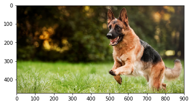

```
you look like a 🐶 ...
German shepherd dog
-------------------------------



hello human 😃
```

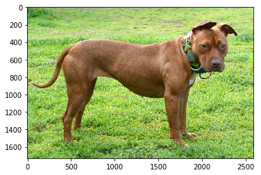

```
you look like a ...
German pinscher
-------------------------------



hello human 😃
```

[figure not shown]

```
you look like a ...
Italian greyhound
-------------------------------



hello human 😃
```

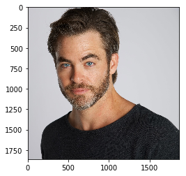

```
you look like a ...
Xoloitzcuintli
-------------------------------



hello human 😃
```

[figure not shown]

```
you look like a ...
Bearded collie
-------------------------------
```

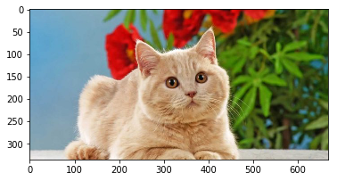

```
error 😑😑: no dog or human found.
-------------------------------
```

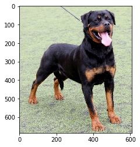

```
you look like a 🐶 ...
Beauceron
-------------------------------
```

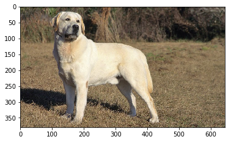

```
you look like a 🐶 ...
Anatolian shepherd dog
-------------------------------
```

```python
## TODO: Execute your algorithm from Step 6 on
## at least 6 images on your computer.
## Feel free to use as many code cells as needed.

## suggested code, below
for file in np.array(glob('imgs/*')):
    run_app(file)
```